# R: Análisis de correlación y Regresión

Cristian Urbano

# 1 Datos

A lo largo de este script usaremos los datos de mtcars. Esta es una base de datos que contiene 32 distintos modelos de carros, su consumo (millas por galón - mpg) y otras variables que pueden ayudar a explicarlo.

```r
library(dplyr)
library(ggplot2)

#Cargamos los datos
datos <- mtcars

head(datos,10)
```

```
##                    mpg cyl  disp  hp drat    wt  qsec vs am gear carb
## Mazda RX4         21.0   6 160.0 110 3.90 2.620 16.46  0  1    4    4
## Mazda RX4 Wag     21.0   6 160.0 110 3.90 2.875 17.02  0  1    4    4
## Datsun 710        22.8   4 108.0  93 3.85 2.320 18.61  1  1    4    1
## Hornet 4 Drive    21.4   6 258.0 110 3.08 3.215 19.44  1  0    3    1
## Hornet Sportabout 18.7   8 360.0 175 3.15 3.440 17.02  0  0    3    2
## Valiant           18.1   6 225.0 105 2.76 3.460 20.22  1  0    3    1
## Duster 360        14.3   8 360.0 245 3.21 3.570 15.84  0  0    3    4
## Merc 240D         24.4   4 146.7  62 3.69 3.190 20.00  1  0    4    2
## Merc 230          22.8   4 140.8  95 3.92 3.150 22.90  1  0    4    2
##  [ reached 'max' / getOption("max.print") -- omitted 1 rows ]
```

# 2 Análisis de correlación

Usamos la correlación de pearson para ver la correlación lineal entre cada par de variables. Para ello usaremos las funciones ggcorr() y ggpairs() del paquete GGally.

Primero instalamos el paquete

```r
install.packages('GGally') #Recuerde que esto solo se hace una vez
```

Y cargamos la librería a nuestro espacio de trabajo

```r
library(GGally)
```

Ya podemos usar la función. Esta solo nos pide poner el data frame.

La manera más simple de hacer este análisisn es usar ggcorr(). Este se limita a mostrar como color la dirección e intensidad de la correlación. Se recomienda usarlo como primer acercamiento a una base de datos. Aquí no importa si hay muchas o pocas variables. A esto se le llama un **correlograma**.

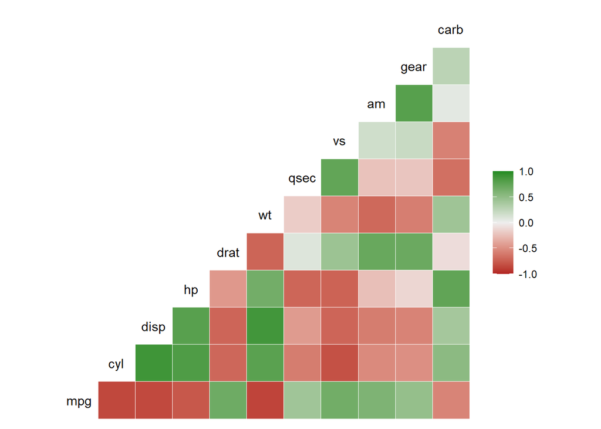

```r
ggcorr(datos, high='forestgreen', low='firebrick')
```

Como podemos ver, nuestra variable de interés (rendimiento - mpg) está muy correlacionada con el peso (wt). Analicemos más detenidamente estas dos variables. Para ello podemos usar ggpairs(), seleccionando dichas variables.

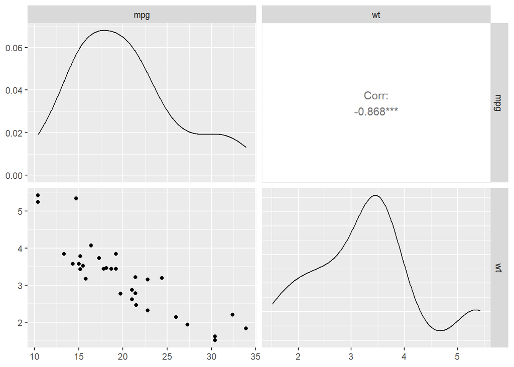

```r
ggpairs(select(datos, mpg, wt))
```

En la diagonal nos muestra el diagrama de densidad de las variables (podemos ver si parecen simétricas, normales, etc.)

Y, finalmente, en la esquina superior derecha nos muestra el coeficiente de correlación de pearson ($\rho$) con su respectivo nivel de significancia.

Recuerde que en este caso la prueba de hipótesis corresponde a

$$H_0 : \rho=0$$
$$H_A : \rho\neq0$$
Por lo tanto, si tiene tres estrellas, significa que rechazamos la hipótesis nula de que la correlación es 0 al 99% de confianza. Así, podemos afirmar que el rendimiento del carro está muy fuertemente correlacionado negativamente con su peso. Esto significa que cuando el peso estpa aumentando, el rendimiento está disminuyendo. Cuidado, **esto no significa que el peso causa la bajada en el rendimiento**. Correlación y causalidad son cosas diferentes.

Para referencia, observe los siguientes ejemplos de correlación que no son causalidad:

https://www.buzzfeednews.com/article/kjh2110/the-10-most-bizarre-correlations

Claramente esto va al absurdo, pero a veces la diferencia entre correlación y causalidad no es tan clara.

En general, las correlaciones se pueden interpretar de acuerdo con la siguiente tabla:

| Coeficiente | Relación |
| --- | --- |
| $\rho\leq0.3$ | Débil o nula |
| $0.3<\rho\leq0.5$ | Moderada |
| $0.5<\rho\leq0.75$ | Fuerte |
| $0.75<\rho\leq1$ | Muy fuerte |

Si queremos sacar solamente el coeficiente de correlación podemos usar cor.test() de la siguiente manera

```r
cor.test(datos$mpg, datos$wt, method = "pearson")
```

```
##
##  Pearson's product-moment correlation
##
## data:  datos$mpg and datos$wt
## t = -9.559, df = 30, p-value = 1.294e-10
## alternative hypothesis: true correlation is not equal to 0
## 95 percent confidence interval:
##  -0.9338264 -0.7440872
## sample estimates:
##        cor
## -0.8676594
```

La interpretación sería la misma que vimos antes. La diferencia es que con ggpairs() podemos comparar varias variables al mismo tiempo.

# 3 Análisis de regresión

Haremos un modelo del rendimiento del carro en función de su peso. Especificando el modelo, tenemos que

$$mpg = \beta_0 + \beta_{1}wt + \varepsilon$$

## 3.1 Regresión

Hacer regresiones en R es bastante sencillo. Para hacerlo usamos la función lm(), su nombre proviene de las iniciales de linear model.

La variable dependiente va primero, luego ponemos ~ y a su derecha las variables independientes separadas por un +. En este caso solo tenemos una, así que podemos escribir la función así

```r
lm(mpg ~ wt, data = datos)
```

```
##
## Call:
## lm(formula = mpg ~ wt, data = datos)
##
## Coefficients:
## (Intercept)           wt
##      37.285       -5.344
```

Para ver los resultados de mejor manera podemos guardar el modelo en un objeto y hacerle un summary()

```r
modelo <- lm(mpg ~ wt, data = datos)

summary(modelo)
```

```
##
## Call:
## lm(formula = mpg ~ wt, data = datos)
##
## Residuals:
##     Min      1Q  Median      3Q     Max
## -4.5432 -2.3647 -0.1252  1.4096  6.8727
##
## Coefficients:
##             Estimate Std. Error t value Pr(>|t|)
## (Intercept)  37.2851     1.8776  19.858  < 2e-16 ***
## wt           -5.3445     0.5591  -9.559 1.29e-10 ***
## ---
## Signif. codes:  0 '***' 0.001 '**' 0.01 '*' 0.05 '.' 0.1 ' ' 1
##
## Residual standard error: 3.046 on 30 degrees of freedom
## Multiple R-squared:  0.7528, Adjusted R-squared:  0.7446
## F-statistic: 91.38 on 1 and 30 DF,  p-value: 1.294e-10
```

Observe que tiene varias partes.

[figure not shown]

En esta simple tabla podemos analizar una buena parte del ejercicio de regresión.

Este es un modelo en el que la independiente y la dependiente entran tal cual (LIN-LIN) por lo que los betas se interpretarían como

$\beta_0:$ Con un 99% de confianza, si el peso fuera 0, el rendimiento por galón sería 37.28 millas.  
$\beta_{1}:$ Con un 99% de confianza, cuando el peso aumenta un kilo, el rendimiento por galón disminuye 5.34 millas en promedio.

Además, pordemos ver que las variaciones en el peso del carro explican un 75.28% de las variaciones en el rendimiento (R-cuadrado)

Y la relación entre estas dos variables es lineal, pues la prueba F se rechaza con un 99% de confianza.

Recuerde que las hipótesis son

$H_0 : \beta_0=\beta_{1}=0$  
$H_A :$ Algún beta es distinto de 0.

Ahora, no podemos creerle a este modelo al menos que chequeemos los supuestos.

## 3.2 Supuestos

### 3.2.1 Normalidad de los errores

La normalidad de los errores se chequea con ks.test(). ks viene de Kolmogorov-Smirnoff. Esta prueba se hace sobre los residuos.

Las hipótesis son:

$H_0 : \varepsilon$ se distribuye normal.  
$H_A : \varepsilon$ no se distribuye normal.

```r
ks.test(modelo$residuals, 'pnorm')
```

```
##
##  One-sample Kolmogorov-Smirnov test
##
## data:  modelo$residuals
## D = 0.3139, p-value = 0.002665
## alternative hypothesis: two-sided
```

Rechazamos la hipótesis nula de normalidad. Podemos concluir que, con un nivel de significacia del 99%, los errores no se distribuyen normal.

Esto nos trae la consecuencia de no poder creerle a los intervalos de confianza de los betas.

### 3.2.2 Homoscedasticidad

La homoscedasticidad se chequea con bptest(), del paquete lmtest. bp viene de Breush-Pagan. Esta prueba se hace sobre el objeto que contiene el modelo, pues la función va a buscar los residuos automáticamente.

Las hipótesis son:

$H_0 :$ Los residuos tienen varianza ($\sigma^2$) constante. Es decir, hay homoscedasticidad.  
$H_A :$ Los residuos no tienen varianza constante. Es decir, hay heteroscedasticidad.

Primero instalamos y cargamos el paquete

```r
install.packages('lmtest')
```

```r
library(lmtest)
```

Y corremos la prueba

```r
bptest(modelo)
```

```
##
##  studentized Breusch-Pagan test
##
## data:  modelo
## BP = 0.040438, df = 1, p-value = 0.8406
```

No rechazamos la hipótesis nula de homoscedasticidad. No hay evidencia suficiente para rechazar la hipótesis nula, por lo que podemos afirmar que los residuos son homoscedasticos.

### 3.2.3 No autocorrelación

La no autocorrelación se chequea con dwtest(), del paquete lmtest. bp viene de Durbin-Watson. Esta prueba se hace sobre el objeto que contiene el modelo, pues la función va a buscar los residuos automáticamente.

Las hipótesis son:

$H_0 :$ Los residuos no están autocorrelacionados.  
$H_A :$ Los residuos están autocorrelacionados.

Como ya tenemos cargado el paquete, corremos la prueba

```r
dwtest(modelo)
```

```
##
##  Durbin-Watson test
##
## data:  modelo
## DW = 1.2517, p-value = 0.0102
## alternative hypothesis: true autocorrelation is greater than 0
```

No rechazamos la hipótesis nula de no autocorrelación al 1% de significancia. No hay evidencia suficiente para rechazar la hipótesis nula, por lo que podemos afirmar que los residuos no están autocorrelacionados.

La autocorrelación es un problema típico de las series de tiempo. Cuando se presenta en un corte transversal (muchos individuos en un solo momento del tiempo), usualmente se debe a omisión de variables relevantes.

## 3.3 Predicción

Asumamos que todos los supuestos se cumplieron (más adelante vermos que hacer en caso de que no). Para predecir nuestra y usando nuestro modelo ($\hat{y}$), podemos usar la función predict().

Podemos indicar el nivel de confianza del intervalo usadon el argumento level. Para el 95%, el código sería

```r
predict(modelo, interval = 'confidence', level = 0.95)
```

```
##                           fit       lwr      upr
## Mazda RX4           23.282611 21.988668 24.57655
## Mazda RX4 Wag       21.919770 20.752751 23.08679
## Datsun 710          24.885952 23.383008 26.38890
## Hornet 4 Drive      20.102650 19.003004 21.20230
## Hornet Sportabout   18.900144 17.771469 20.02882
## Valiant             18.793255 17.659216 19.92729
## Duster 360          18.205363 17.034274 19.37645
## Merc 240D           20.236262 19.136179 21.33635
## Merc 230            20.450041 19.347720 21.55236
## Merc 280            18.900144 17.771469 20.02882
## Merc 280C           18.900144 17.771469 20.02882
## Merc 450SE          15.533127 14.064349 17.00190
## Merc 450SL          17.350247 16.104455 18.59604
## Merc 450SLC         17.083024 15.809403 18.35664
## Cadillac Fleetwood   9.226650  6.658271 11.79503
## Lincoln Continental  8.296712  5.547468 11.04596
## Chrysler Imperial    8.718926  6.052112 11.38574
## Fiat 128            25.527289 23.927797 27.12678
## Honda Civic         28.653805 26.519252 30.78836
## Toyota Corolla      27.478021 25.554415 29.40163
## Toyota Corona       24.111004 22.715653 25.50635
## Dodge Challenger    18.472586 17.319886 19.62529
## AMC Javelin         18.926866 17.799465 20.05427
## Camaro Z28          16.762355 15.452833 18.07188
## Pontiac Firebird    16.735633 15.423002 18.04826
## Fiat X1-9           26.943574 25.112491 28.77466
## Porsche 914-2       25.847957 24.198041 27.49787
## Lotus Europa        29.198941 26.963760 31.43412
## Ford Pantera L      20.343151 19.242185 21.44412
## Ferrari Dino        22.480940 21.268498 23.69338
## Maserati Bora       18.205363 17.034274 19.37645
## Volvo 142E          22.427495 21.219818 23.63517
```

Pero es más útil añadirlo a nuestro data frame para poder comparar y hacer un gráfico

```r
#Guarda la predicción en un objeto
fit <- predict(modelo, interval = 'confidence', level = 0.95)

#Añade la predicción, el upper bound y el lower bound del intervalo de confianza al data frame
datos_fit <- cbind(datos, fit)
```

Para hacer el gráfico podemos usar ggplot(). Es importante conservar el orden de las variables (en y debe ir la dependiente y en x la independiente).

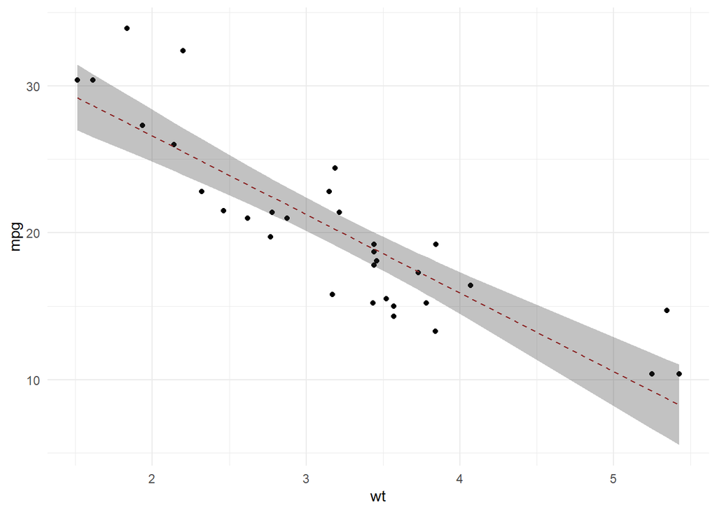

```r
ggplot(datos_fit, aes(x=wt, y=mpg)) +
  geom_point() + #Hace el gráfico de dispersión
  geom_line(aes(x=wt, y=fit), #Añade la línea de regresión
            color='firebrick',
            linetype='dashed') +
  geom_ribbon(aes(ymax=upr, ymin=lwr), alpha = 0.3) + #Añade el intervalo
  theme_minimal()
```

## 3.4 Solución de problemas

### 3.4.1 No normalidad

Cuando los errores no se comportan normal, es necesario hacer pruebas estadísticas no paramétricas (que no requieran el supuesto de normalidad) si las muestras son pequeñas. No paramétrico significa que no asumen una distribución a priori, sino que la construyen a partir de los datos.

Si las muestras son grandes ($n>30$), es posible apelar al Teorema del Límite Central. Aunque es necesario revisar el problema a fondo y chequear que no haya un problema de especificación.

Otra solución es usar modelos de regresión no paramétricos, como la regresión cuantílica.

### 3.4.2 Heteroscedasticidad

Cuando hay heteroscedaticidad es posible usar unos errores estándar consistentes en presencia de este problema. Para hacerlo, podemos usar la función coeftest() del paquete lmtest junto a la función vcovHC() del paquete sandwich.

```r
install.packages('sandwich')
```

```r
library(sandwich)
```

Se usa de esta manera

```r
coeftest(modelo, vcov. = vcovHC(modelo, type = "HC1"))
```

```
##
## t test of coefficients:
##
##             Estimate Std. Error t value  Pr(>|t|)
## (Intercept) 37.28513    2.19498 16.9865 < 2.2e-16 ***
## wt          -5.34447    0.65448 -8.1659 4.084e-09 ***
## ---
## Signif. codes:  0 '***' 0.001 '**' 0.01 '*' 0.05 '.' 0.1 ' ' 1
```

Los tests de significancia individual ahora serán consistentes aún cuando haya problemas de heteroscedasticidad.

### 3.4.3 Autocorrelación

Parecido al caso anterior, cuando hay autocorrelación es posible usar unos errores estándar consistentes en presencia de este problema. Para hacerlo, podemos usar la función coeftest() del paquete lmtest junto a la función vcovHC() del paquete sandwich. Pero en lugar de vcovHC usamos vcovHAC

```r
coeftest(modelo, vcov. = vcovHAC(modelo))
```

```
##
## t test of coefficients:
##
##             Estimate Std. Error t value  Pr(>|t|)
## (Intercept) 37.28513    1.92480 19.3709 < 2.2e-16 ***
## wt          -5.34447    0.58787 -9.0913 4.008e-10 ***
## ---
## Signif. codes:  0 '***' 0.001 '**' 0.01 '*' 0.05 '.' 0.1 ' ' 1
```

Los tests de significancia individual ahora serán consistentes aún cuando haya problemas de heteroscedasticidad y/o de autocorrelación. Sin embargo, es importante mencionar que la autocorrelación debería ser un problema en datos de series de tiempo. En la mayoría de los otros casos, suele deberse a mala especificación del modelo.

Otras soluciones para la heteroscedasticidad y la autocorrelación son estimar el modelo por mínimos cuadrados generalizados (GLS), o hacer correcciones como la de Newey-West, pero esto no lo cubriremos.

## 3.5 Selección de variables

Cuando tenemos un data frame con muchas variables, quizá no sepamos exactamente que variables incluir en el modelo. Hay técnicas de minería de datos para solucionar este problema.

La stepwise regression (regresión en pasos) va cambiando las variables del modelo de regresión para ver cuáles aportan información y cuales no. Para medir esto se usan criterios de información, como el AIC y el BIC o el R-cuadrado.

Para realizar este proceso en R se usa la función regsubsets() del paquete leaps

```r
install.packages('leaps')
```

```r
library(leaps)
```

Le decimos a la función cual es nuestra dependiente, cuales podrían ser las independientes. nvmax le dice hasta máximo cuantas variables queremos.

```r
stepwise_forward <- regsubsets(x= select(datos, -mpg), y=datos$mpg, method = 'forward',
            nvmax = 8, intercept = TRUE)

sum_swf <- summary(stepwise_forward)

sum_swf
```

```
## Subset selection object
## 10 Variables  (and intercept)
##      Forced in Forced out
## cyl      FALSE      FALSE
## disp     FALSE      FALSE
## hp       FALSE      FALSE
## drat     FALSE      FALSE
## wt       FALSE      FALSE
## qsec     FALSE      FALSE
## vs       FALSE      FALSE
## am       FALSE      FALSE
## gear     FALSE      FALSE
## carb     FALSE      FALSE
## 1 subsets of each size up to 8
## Selection Algorithm: forward
##          cyl disp hp  drat wt  qsec vs  am  gear carb
## 1  ( 1 ) " " " "  " " " "  "*" " "  " " " " " "  " "
## 2  ( 1 ) "*" " "  " " " "  "*" " "  " " " " " "  " "
## 3  ( 1 ) "*" " "  "*" " "  "*" " "  " " " " " "  " "
## 4  ( 1 ) "*" " "  "*" " "  "*" " "  " " "*" " "  " "
## 5  ( 1 ) "*" " "  "*" " "  "*" "*"  " " "*" " "  " "
## 6  ( 1 ) "*" "*"  "*" " "  "*" "*"  " " "*" " "  " "
## 7  ( 1 ) "*" "*"  "*" "*"  "*" "*"  " " "*" " "  " "
## 8  ( 1 ) "*" "*"  "*" "*"  "*" "*"  " " "*" "*"  " "
```

Como puede notar, nos devuelve el mejor modelo para cada número de variables. Podemos ver con cual quedarnos viendo el comportamiento del R-cuadrado (o cualquier otro criterio como el BIC, aunque ese se minimiza).

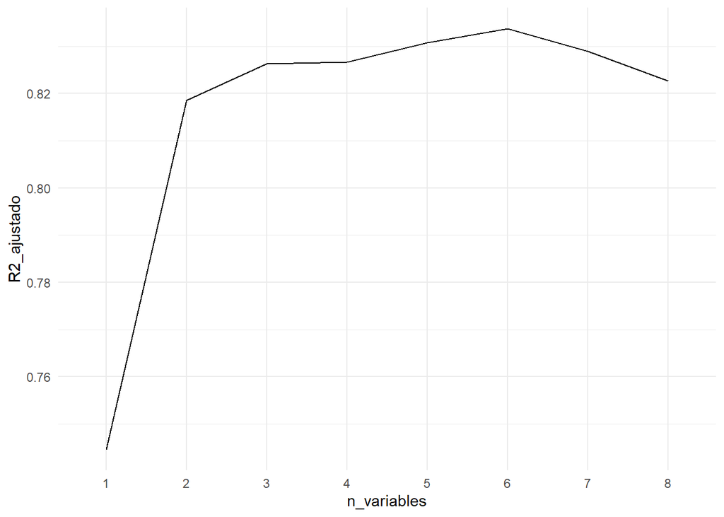

```r
sum_swf_df <- data.frame('n_variables'= as.character(c(1:8)),
                         'R2_ajustado'= sum_swf$adjr2,
                         'BIC' = sum_swf$bic)

ggplot(sum_swf_df, aes(y = R2_ajustado, x = n_variables, group = 1)) +
  geom_line() +
  theme_minimal()
```

Si usamos como criterio el R-cuadrado ajustado, nos quedamos con el modelo con dos variables (más el intercepto), pues las variables adicionales no aportan mucho.

Así, nuestro modelo final es

```r
modelo_final <- lm(mpg ~ wt + cyl, data = datos)

summary(modelo_final)
```

```
##
## Call:
## lm(formula = mpg ~ wt + cyl, data = datos)
##
## Residuals:
##     Min      1Q  Median      3Q     Max
## -4.2893 -1.5512 -0.4684  1.5743  6.1004
##
## Coefficients:
##             Estimate Std. Error t value Pr(>|t|)
## (Intercept)  39.6863     1.7150  23.141  < 2e-16 ***
## wt           -3.1910     0.7569  -4.216 0.000222 ***
## cyl          -1.5078     0.4147  -3.636 0.001064 **
## ---
## Signif. codes:  0 '***' 0.001 '**' 0.01 '*' 0.05 '.' 0.1 ' ' 1
##
## Residual standard error: 2.568 on 29 degrees of freedom
## Multiple R-squared:  0.8302, Adjusted R-squared:  0.8185
## F-statistic: 70.91 on 2 and 29 DF,  p-value: 6.809e-12
```

Tenga en cuenta que aquí solo mostramos el método forward, también existe el backward y el exhaustivo. El forward empieza con el modelo con el intercepto y va ingresando variables hasta encontrar el mejor para cada tamaño. El backward empieza con el modelo completo y va quitando variables. El exhaustivo prueba todas las combinaciones, pero puede ser demorado el datasets más grandes.

## 3.6 Presentación de resultados

Finalmente, estamos listos para sacar nuestros resultados y mostrarlos al mundo. Para hacer esto podemos usar la librería stargazer.

```r
install.packages('stargazer')
```

```r
library(stargazer)
```

Este paquete tiene la posibilidad de generar tablas en R markdown (html), pdf (latex) o texto plano. Tiene una gran cantidad de opciones de personalización. Pero a veces basta con solo usar el siguiente código.

```r
stargazer(modelo_final, type = 'html', star.char = '*')
```

|  | *Dependent variable:* |
| --- | --- |
|  | mpg |
| wt | -3.191*** |
|  | (0.757) |
| cyl | -1.508*** |
|  | (0.415) |
| Constant | 39.686*** |
|  | (1.715) |
| Observations | 32 |
| R<sup>2</sup> | 0.830 |
| Adjusted R<sup>2</sup> | 0.819 |
| Residual Std. Error | 2.568 (df = 29) |
| F Statistic | 70.908*** (df = 2; 29) |
| *Note:* | p<0.1; p<0.05; p<0.01 |

Si queremos la tabla para Word, podemos sacarla en texto plano y copiarla

```r
stargazer(modelo_final, type = 'text')
```

```
##
## ===============================================
##                         Dependent variable:
##                     ---------------------------
##                                 mpg
## -----------------------------------------------
## wt                           -3.191***
##                               (0.757)
##
## cyl                          -1.508***
##                               (0.415)
##
## Constant                     39.686***
##                               (1.715)
##
## -----------------------------------------------
## Observations                    32
## R2                             0.830
## Adjusted R2                    0.819
## Residual Std. Error       2.568 (df = 29)
## F Statistic           70.908*** (df = 2; 29)
## ===============================================
## Note:               *p<0.1; **p<0.05; ***p<0.01
```

```r
library(kableExtra)
library(xtable)

modelo_final %>%
  xtable() %>%
  kable() %>%
  kable_styling()
```

|  | Estimate | Std. Error | t value | Pr(>\|t\|) |
| --- | --- | --- | --- | --- |
| (Intercept) | 39.686262 | 1.7149840 | 23.140893 | 0.0000000 |
| wt | -3.190972 | 0.7569065 | -4.215808 | 0.0002220 |
| cyl | -1.507795 | 0.4146883 | -3.635972 | 0.0010643 |